# multifinedustprophet

### Predictive modeling of historical fine dust data in South Korea

Fine dust and other sources of air pollution impose a significant toll on human health, often perceived as the inevitable cost of economic prosperity. This project will utilize historical data of fine dust (PM10) concentrations, as recorded by the Suwon weather station (station number 119), to explore the following questions:

1. Are there significant trends such as yearly and seasonal in measured fine dust concentration?
2. Are there significant “one-off” events across time where fine dust levels were noticeably higher or lower than the historical record would suggest?
3. How do other environmental conditions, such as rainfall or traffic volume, impact fine dust concentration?
4. Can the observed trends and patterns in the data be extrapolated to the future?

The questions are investigated using Prophet library, https://facebook.github.io/prophet/ , as it provides modeling for time series data and allows to incorporate extra-regressors.

The historical fine dust concentration data will be divided into a train set and a test set. The Prophet model will first be applied to the train dataset and subsequently tested for its effectiveness on the test dataset. Initially, the first model will be based solely on the fine dust data. Later, a second model will incorporate additional environmental variables as extra regressors, such as rainfall or traffic volume.

The investigation begins with an examination of the historical fine dust data. The fine dust data is available in  
https://data.kma.go.kr/data/climate/selectDustRltmList.do?pgmNo=68

- This notebook entierly follows the methods shown in the work https://nbviewer.org/github/nicolasfauchereau/Auckland_Cycling/blob/master/notebooks/Auckland_cycling_and_weather.ipynb

#### Import libraries

```python
%matplotlib inline
#import warnings
#warnings.simplefilter("ignore", DeprecationWarning)
#warnings.simplefilter("ignore", FutureWarning, )
from glob import glob
import numpy as np
import pandas as pd
from matplotlib import pyplot as plt
import seaborn as sns
from sklearn.metrics import mean_absolute_error as MAE
from scipy.stats import skew
from calendar import day_abbr, month_abbr, mdays, isleap
import holidays
from prophet import Prophet
import utils
```

```
c:\users\hyochan heo\appdata\local\programs\python\python38\lib\site-packages\tqdm\auto.py:21: TqdmWarning: IProgress not found. Please update jupyter and ipywidgets. See https://ipywidgets.readthedocs.io/en/stable/user_install.html
  from .autonotebook import tqdm as notebook_tqdm
Importing plotly failed. Interactive plots will not work.
```

#### Read the fine dust data

```python
lfiles = glob('ENV_YDST_119_HR_????_????_????.csv')
```

```python
lfiles
```

```
['ENV_YDST_119_HR_2013_2013_2017.csv',
 'ENV_YDST_119_HR_2014_2014_2017.csv',
 'ENV_YDST_119_HR_2015_2015_2017.csv',
 'ENV_YDST_119_HR_2016_2016_2017.csv',
 'ENV_YDST_119_HR_2017_2017_2018.csv',
 'ENV_YDST_119_HR_2018_2018_2019.csv',
 'ENV_YDST_119_HR_2019_2019_2020.csv',
 'ENV_YDST_119_HR_2020_2020_2021.csv',
 'ENV_YDST_119_HR_2021_2021_2022.csv',
 'ENV_YDST_119_HR_2022_2022_2023.csv']
```

```python
l = []
for f in lfiles:
    d = pd.read_csv(f, index_col=1, parse_dates=True, encoding="cp949")
    d.rename(columns={'1시간평균 미세먼지농도(㎍/㎥)': 'fdust_per_h'}, inplace=True)
    l.append(d)
l[0].rename(columns={'시간': '일시'}, inplace=True)
```

```python
df = pd.concat(l, axis=0)
```

```python
df
```

|  | 지점 | fdust_per_h |
| --- | --- | --- |
| 2013-01-01 01:00:00 | 119 | 47.0 |
| 2013-01-01 02:00:00 | 119 | 45.0 |
| 2013-01-01 03:00:00 | 119 | 38.0 |
| 2013-01-01 04:00:00 | 119 | 47.0 |
| 2013-01-01 05:00:00 | 119 | 37.0 |
| ... | ... | ... |
| 2022-12-31 19:00:00 | 119 | 50.0 |
| 2022-12-31 20:00:00 | 119 | 54.0 |
| 2022-12-31 21:00:00 | 119 | 62.0 |
| 2022-12-31 22:00:00 | 119 | 64.0 |
| 2022-12-31 23:00:00 | 119 | 67.0 |

86705 rows × 2 columns

```python
df = df.clip(0,)
```

```python
df.loc[df['fdust_per_h']==0]
```

|  | 지점 | fdust_per_h |
| --- | --- | --- |
| 2017-07-10 13:00:00 | 119 | 0.0 |

```python
df.index
```

```
DatetimeIndex(['2013-01-01 01:00:00', '2013-01-01 02:00:00',
               '2013-01-01 03:00:00', '2013-01-01 04:00:00',
               '2013-01-01 05:00:00', '2013-01-01 06:00:00',
               '2013-01-01 07:00:00', '2013-01-01 08:00:00',
               '2013-01-01 09:00:00', '2013-01-01 10:00:00',
               ...
               '2022-12-31 14:00:00', '2022-12-31 15:00:00',
               '2022-12-31 16:00:00', '2022-12-31 17:00:00',
               '2022-12-31 18:00:00', '2022-12-31 19:00:00',
               '2022-12-31 20:00:00', '2022-12-31 21:00:00',
               '2022-12-31 22:00:00', '2022-12-31 23:00:00'],
              dtype='datetime64[ns]', length=86705, freq=None)
```

#### Make dataframe only contains concentration and its measured time

```python
Finedust = df.loc[:, 'fdust_per_h'] # In [50]
```

```python
Finedust = Finedust.to_frame(name='fdust_per_h')
```

```python
Finedust.isnull().sum()
```

```
fdust_per_h    2365
dtype: int64
```

It has 2365 empty value

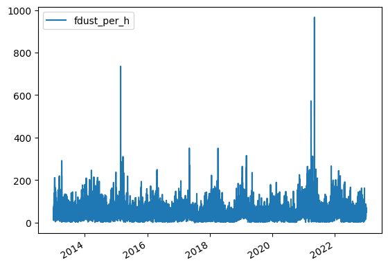

```python
Finedust.plot()
```

It shows some peak values, and the concentration data seems has seasonal trend, no clear trend through the years.

#### Plots the seasonal cycle

```python
seas_cycl = df.loc[:,'fdust_per_h'].rolling(window=30*24, center=True, min_periods=20).mean().groupby(df.index.dayofyear).mean()
```

```python
q25 = df.loc[:,'fdust_per_h'].rolling(window=30*24, center=True, min_periods=20).mean().groupby(df.index.dayofyear).quantile(0.25)
q75 = df.loc[:,'fdust_per_h'].rolling(window=30*24, center=True, min_periods=20).mean().groupby(df.index.dayofyear).quantile(0.75)
```

```python
ndays_m = mdays.copy()
ndays_m[2] = 29
```

```python
ndays_m = np.cumsum(ndays_m)
```

```python
month_abbr = month_abbr[1:]
month_abbr.append('')
```

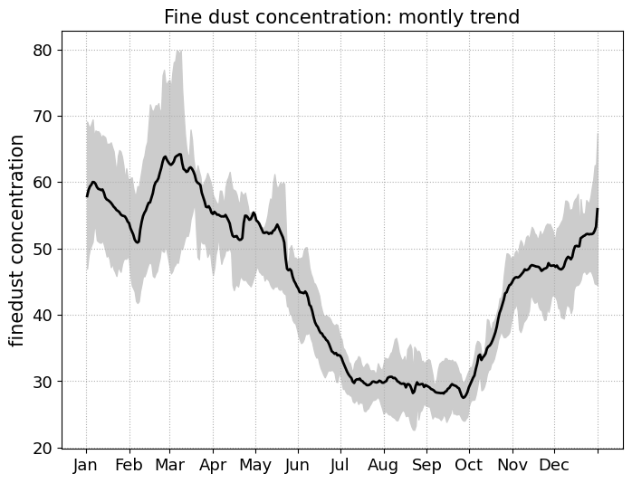

```python
f, ax = plt.subplots(figsize=(8,6))

seas_cycl.plot(ax=ax, lw=2, color='k', legend=False)

ax.fill_between(seas_cycl.index, q25.values.ravel(), q75.values.ravel(), color='0.8')

ax.set_xticks(ndays_m)
ax.set_xticklabels(month_abbr)

ax.grid(ls=':')

ax.set_xlabel('', fontsize=15)

ax.set_ylabel('finedust concentration', fontsize=15);

[l.set_fontsize(13) for l in ax.xaxis.get_ticklabels()]
[l.set_fontsize(13) for l in ax.yaxis.get_ticklabels()]

ax.set_title('Fine dust concentration: montly trend', fontsize=15)
```

It shows clear seasonal trend, peaks at winter-spring and has low value at summer (Jul to Oct)  
It suggests that the concentration data largely depends on environmental factor(s), might include rainfall or monsoon.

#### Plots daily and weekly trend

```python
hour_week = df.loc[:,['fdust_per_h']].copy()
```

```python
hour_week.loc[:,'day_of_week'] = hour_week.index.dayofweek
hour_week.loc[:,'hour'] = hour_week.index.hour
```

```python
hour_week = hour_week.groupby(['day_of_week','hour']).mean().unstack()
```

```python
hour_week.columns = hour_week.columns.droplevel(0)
```

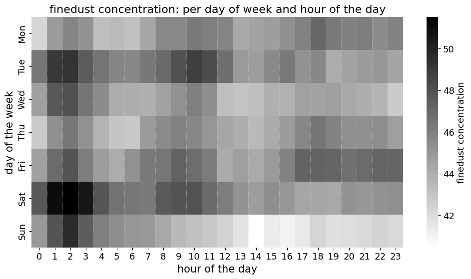

```python
f, ax = plt.subplots(figsize=(12,6))

sns.heatmap(hour_week, ax = ax, cmap=plt.cm.gray_r)

cbax = f.axes[1]
[l.set_fontsize(13) for l in cbax.yaxis.get_ticklabels()]
cbax.set_ylabel('finedust concentration', fontsize=13)

[ax.axhline(x, ls=':', lw=0.5, color='0.8') for x in np.arange(1, 7)]
[ax.axvline(x, ls=':', lw=0.5, color='0.8') for x in np.arange(1, 24)];

ax.set_title('finedust concentration: per day of week and hour of the day', fontsize=16)

[l.set_fontsize(13) for l in ax.xaxis.get_ticklabels()]
[l.set_fontsize(13) for l in ax.yaxis.get_ticklabels()]

ax.set_xlabel('hour of the day', fontsize=15)
ax.set_ylabel('day of the week', fontsize=15)
ax.set_yticklabels(day_abbr[0:7]);
```

It shows not clear trend, but around 2 am gives higher concentration than other times, especially in saturday of saterday it has notably high concentration. I cannot think out proper reason of such trend. But one thing I can suggest is due to the traffic, with assumption that

1. Fine dust can be emitted by traffic,
2. At the transition from weekday to weekend the traffic peaks,
3. The fine dust is trapped at stable atmosphere layer at late evening as suggested (peaks at21:00 ~ 23:00) https://pubs.acs.org/doi/abs/10.1021/acs.estlett.8b00573

And the difference in peaks time is might due to geographical difference with the study, or it is from surrounding country with time difference of floating into.

#### Looking at the trend week days versus weekends

```python
weekdays = df.loc[df.index.day_name().isin(['Monday','Tuesday','Wednesday','Thursday','Friday']), 'fdust_per_h']
weekends = df.loc[df.index.day_name().isin(['Sunday','Saturday']), 'fdust_per_h']
```

```python
summary_hour_weekdays = weekdays.groupby(weekdays.index.hour).describe()
summary_hour_weekends = weekends.groupby(weekends.index.hour).describe()
```

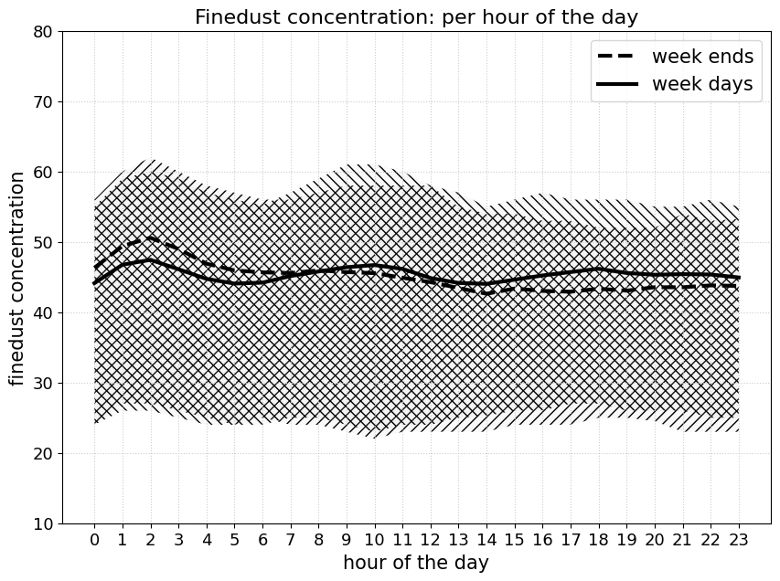

```python
f, ax = plt.subplots(figsize=(10,7))

ax.plot(summary_hour_weekends.index, summary_hour_weekends.loc[:,'mean'], color='k', label='week ends', ls='--', lw=3)

ax.fill_between(summary_hour_weekends.index, summary_hour_weekends.loc[:,'25%'], \
                summary_hour_weekends.loc[:,'75%'], hatch='///', facecolor='0.8', alpha=0.1)

ax.set_xticks(range(24));

ax.grid(ls=':', color='0.8')

# ax.set_title('week-ends', fontsize=16)

ax.plot(summary_hour_weekdays.index, summary_hour_weekdays.loc[:,'mean'], color='k', label='week days', lw=3)

ax.fill_between(summary_hour_weekdays.index, summary_hour_weekdays.loc[:,'25%'], \
                summary_hour_weekdays.loc[:,'75%'], hatch='\\\\\\', facecolor='0.8', alpha=0.1)

ax.legend(loc=1 , fontsize=15)

ax.set_xticks(range(24));

ax.grid(ls=':', color='0.8')

ax.set_ylim([10, 80])

ax.set_xlabel('hour of the day', fontsize=15)

ax.set_ylabel('finedust concentration', fontsize=15);

[l.set_fontsize(13) for l in ax.xaxis.get_ticklabels()]
[l.set_fontsize(13) for l in ax.yaxis.get_ticklabels()]

ax.set_title('Finedust concentration: per hour of the day', fontsize=16)
```

It shows not clear difference, but in ealy of the day weekends have higner value than week days, reminding the peaks at 2 am in Saturday of the previous figure. From morning, week days have higher value than weekends, slightly suggesting that fine dust concentration is from human activity.

#### calculates the daily avarage from the hourly data

```python
data = df.loc['2013':,['fdust_per_h']].resample('1D').mean()
```

This 'data' dataframe will be used for further anlysis

```python
data
```

|  | fdust_per_h |
| --- | --- |
| 2013-01-01 | 41.173913 |
| 2013-01-02 | 23.750000 |
| 2013-01-03 | 29.000000 |
| 2013-01-04 | 53.458333 |
| 2013-01-05 | 65.333333 |
| ... | ... |
| 2022-12-27 | 58.416667 |
| 2022-12-28 | 44.791667 |
| 2022-12-29 | 44.500000 |
| 2022-12-30 | 49.625000 |
| 2022-12-31 | 57.875000 |

3652 rows × 1 columns

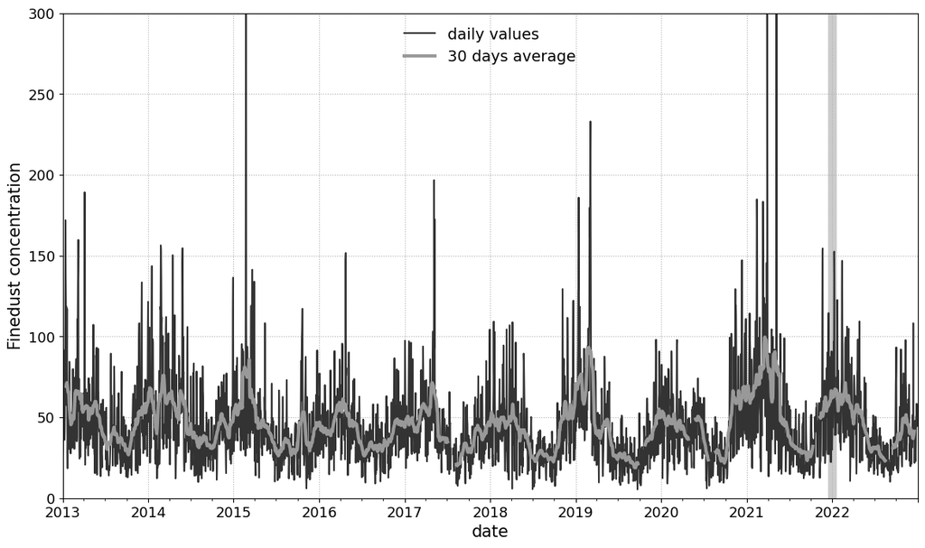

```python
f, ax = plt.subplots(figsize=(14,8))

data.plot(ax=ax, color='0.2')

data.rolling(window=30, center=True).mean().plot(ax=ax, ls='-', lw=3, color='0.6')

ax.grid(ls=':')
ax.legend(['daily values','30 days average'], frameon=False, fontsize=14)

[l.set_fontsize(13) for l in ax.xaxis.get_ticklabels()]
[l.set_fontsize(13) for l in ax.yaxis.get_ticklabels()]

ax.set_xlabel('date', fontsize=15)

ax.set_ylim([0, 300])
ax.set_ylabel('Finedust concentration', fontsize=15);

ax.axvline('2022', color='0.8', lw=8, zorder=-1)
```

It again shows seasonal trend that agree with above figure (which is by Finedust.plot()), also showing gentle incerase of the concentration in 2021

#### creates a pandas dataframe holding the dates of the holidays (national holidays)

This dataframe will be used for Prophet model

```python
holidays_df = pd.DataFrame([], columns = ['ds','holiday'])
```

```python
ldates = []
lnames = []
for date, name in sorted(holidays.KR(years=np.arange(2013, 2022 + 1)).items()):
    ldates.append(date)
    lnames.append(name)
```

```python
ldates = np.array(ldates)
lnames = np.array(lnames)
```

```python
holidays_df.loc[:,'ds'] = ldates
holidays_df.loc[:,'holiday'] = lnames
holidays_df
```

|  | ds | holiday |
| --- | --- | --- |
| 0 | 2013-01-01 | 신정연휴 |
| 1 | 2013-02-09 | 설날 전날 |
| 2 | 2013-02-10 | 설날 |
| 3 | 2013-02-11 | 설날 다음날 |
| 4 | 2013-03-01 | 삼일절 |
| ... | ... | ... |
| 169 | 2022-09-12 | 추석 대체 휴일 |
| 170 | 2022-10-03 | 개천절 |
| 171 | 2022-10-09 | 한글날 |
| 172 | 2022-10-10 | 한글날 대체 휴일 |
| 173 | 2022-12-25 | 기독탄신일 |

174 rows × 2 columns

```python
holidays_df.holiday.unique()
```

```
array(['신정연휴', '설날 전날', '설날', '설날 다음날', '삼일절', '어린이날', '석가탄신일', '현충일',
       '광복절', '추석 전날', '추석', '추석 다음날', '개천절', '한글날', '기독탄신일', '지방선거일',
       '추석 대체 휴일', '임시공휴일', '설날 대체 휴일', '국회의원 선거일', '부처님오신날', '대통령 선거일',
       '개천절; 추석 전날', '어린이날 대체 휴일', '광복절 대체 휴일', '개천절 대체 휴일', '한글날 대체 휴일'],
      dtype=object)
```

Prepares the daily fine dust concentration data to feed Prophet model

```python
data = data.rename({'fdust_per_h':'y'}, axis=1)
```

```python
data
```

|  | y |
| --- | --- |
| 2013-01-01 | 41.173913 |
| 2013-01-02 | 23.750000 |
| 2013-01-03 | 29.000000 |
| 2013-01-04 | 53.458333 |
| 2013-01-05 | 65.333333 |
| ... | ... |
| 2022-12-27 | 58.416667 |
| 2022-12-28 | 44.791667 |
| 2022-12-29 | 44.500000 |
| 2022-12-30 | 49.625000 |
| 2022-12-31 | 57.875000 |

3652 rows × 1 columns

#### Splits the data into train and test dataset

last one yeas is dedicated for test dataset

```python
data_train = data.loc[:'2021',:]
data_test = data.loc['2022':,:]
data_train.reset_index(inplace=True)
data_test.reset_index(inplace=True)
data_train = data_train.rename({'index':'ds'}, axis=1)
data_test = data_test.rename({'index':'ds'}, axis=1)
data_train = data_train.interpolate(method='linear') #added
data_test = data_test.interpolate(method='linear') #added
(data_train, data_test)
```

```
(             ds          y
 0    2013-01-01  41.173913
 1    2013-01-02  23.750000
 2    2013-01-03  29.000000
 3    2013-01-04  53.458333
 4    2013-01-05  65.333333
 ...         ...        ...
 3282 2021-12-27  42.541667
 3283 2021-12-28  79.708333
 3284 2021-12-29  90.863636
 3285 2021-12-30  37.000000
 3286 2021-12-31  29.916667

 [3287 rows x 2 columns],
             ds          y
 0   2022-01-01  39.333333
 1   2022-01-02  62.625000
 2   2022-01-03  43.916667
 3   2022-01-04  54.208333
 4   2022-01-05  74.375000
 ..         ...        ...
 360 2022-12-27  58.416667
 361 2022-12-28  44.791667
 362 2022-12-29  44.500000
 363 2022-12-30  49.625000
 364 2022-12-31  57.875000

 [365 rows x 2 columns])
```

#### Fit the model to the training data

```python
m1 = Prophet(mcmc_samples=300, holidays=holidays_df, holidays_prior_scale=0.25, changepoint_prior_scale=0.005, seasonality_mode='multiplicative', \
            yearly_seasonality=15, \
            weekly_seasonality=True, \
            daily_seasonality=False)
```

```python
m1.fit(data_train)
```

[output not shown]

[output not shown]

```
<prophet.forecaster.Prophet at 0x292e6b62880>
```

#### Make the future dataframe, contains periods of train set and test set

```python
future = m1.make_future_dataframe(periods=len(data_test), freq='1D')
future
```

|  | ds |
| --- | --- |
| 0 | 2013-01-01 |
| 1 | 2013-01-02 |
| 2 | 2013-01-03 |
| 3 | 2013-01-04 |
| 4 | 2013-01-05 |
| ... | ... |
| 3647 | 2022-12-27 |
| 3648 | 2022-12-28 |
| 3649 | 2022-12-29 |
| 3650 | 2022-12-30 |
| 3651 | 2022-12-31 |

3652 rows × 1 columns

#### Make forecast on peroids on future

```python
forecast = m1.predict(future)
```

```python
forecast
```

|  | ds | trend | yhat_lower | yhat_upper | trend_lower | trend_upper | holidays | holidays_lower | holidays_upper | multiplicative_terms | ... | 한글날 대체 휴일 | 한글날 대체 휴일_lower | 한글날 대체 휴일_upper | 현충일 | 현충일_lower | 현충일_upper | additive_terms | additive_terms_lower | additive_terms_upper | yhat |
| --- | --- | --- | --- | --- | --- | --- | --- | --- | --- | --- | --- | --- | --- | --- | --- | --- | --- | --- | --- | --- | --- |
| 0 | 2013-01-01 | 49.424805 | 30.475525 | 98.233753 | 47.647869 | 51.168098 | 0.066367 | -0.125697 | 0.256316 | 0.280388 | ... | 0.0 | 0.0 | 0.0 | 0.0 | 0.0 | 0.0 | 0.0 | 0.0 | 0.0 | 63.282926 |
| 1 | 2013-01-02 | 49.418664 | 25.374232 | 92.965718 | 47.645525 | 51.160975 | 0.000000 | 0.000000 | 0.000000 | 0.183196 | ... | 0.0 | 0.0 | 0.0 | 0.0 | 0.0 | 0.0 | 0.0 | 0.0 | 0.0 | 58.471987 |
| 2 | 2013-01-03 | 49.412522 | 26.845801 | 92.729454 | 47.643180 | 51.152143 | 0.000000 | 0.000000 | 0.000000 | 0.213832 | ... | 0.0 | 0.0 | 0.0 | 0.0 | 0.0 | 0.0 | 0.0 | 0.0 | 0.0 | 59.978491 |
| 3 | 2013-01-04 | 49.406381 | 28.207374 | 95.082234 | 47.640835 | 51.142573 | 0.000000 | 0.000000 | 0.000000 | 0.257453 | ... | 0.0 | 0.0 | 0.0 | 0.0 | 0.0 | 0.0 | 0.0 | 0.0 | 0.0 | 62.126194 |
| 4 | 2013-01-05 | 49.400239 | 33.050686 | 97.672673 | 47.638601 | 51.132988 | 0.000000 | 0.000000 | 0.000000 | 0.290817 | ... | 0.0 | 0.0 | 0.0 | 0.0 | 0.0 | 0.0 | 0.0 | 0.0 | 0.0 | 63.766691 |
| ... | ... | ... | ... | ... | ... | ... | ... | ... | ... | ... | ... | ... | ... | ... | ... | ... | ... | ... | ... | ... | ... |
| 3647 | 2022-12-27 | 58.630501 | 36.693298 | 103.032233 | 55.492896 | 61.788648 | 0.000000 | 0.000000 | 0.000000 | 0.186592 | ... | 0.0 | 0.0 | 0.0 | 0.0 | 0.0 | 0.0 | 0.0 | 0.0 | 0.0 | 69.570469 |
| 3648 | 2022-12-28 | 58.643593 | 33.927634 | 101.298926 | 55.501405 | 61.804225 | 0.000000 | 0.000000 | 0.000000 | 0.140563 | ... | 0.0 | 0.0 | 0.0 | 0.0 | 0.0 | 0.0 | 0.0 | 0.0 | 0.0 | 66.886734 |
| 3649 | 2022-12-29 | 58.656685 | 34.139383 | 101.869409 | 55.510278 | 61.819291 | 0.000000 | 0.000000 | 0.000000 | 0.155559 | ... | 0.0 | 0.0 | 0.0 | 0.0 | 0.0 | 0.0 | 0.0 | 0.0 | 0.0 | 67.781257 |
| 3650 | 2022-12-30 | 58.669777 | 36.210381 | 102.623239 | 55.519293 | 61.830567 | 0.000000 | 0.000000 | 0.000000 | 0.183886 | ... | 0.0 | 0.0 | 0.0 | 0.0 | 0.0 | 0.0 | 0.0 | 0.0 | 0.0 | 69.458333 |
| 3651 | 2022-12-31 | 58.682869 | 37.644683 | 103.099596 | 55.528309 | 61.841291 | 0.000000 | 0.000000 | 0.000000 | 0.203084 | ... | 0.0 | 0.0 | 0.0 | 0.0 | 0.0 | 0.0 | 0.0 | 0.0 | 0.0 | 70.600422 |

3652 rows × 103 columns

#### Plots the components of the forecast

It includes overall trend, cyclic trend (weekly and yearly), effect of each holidays

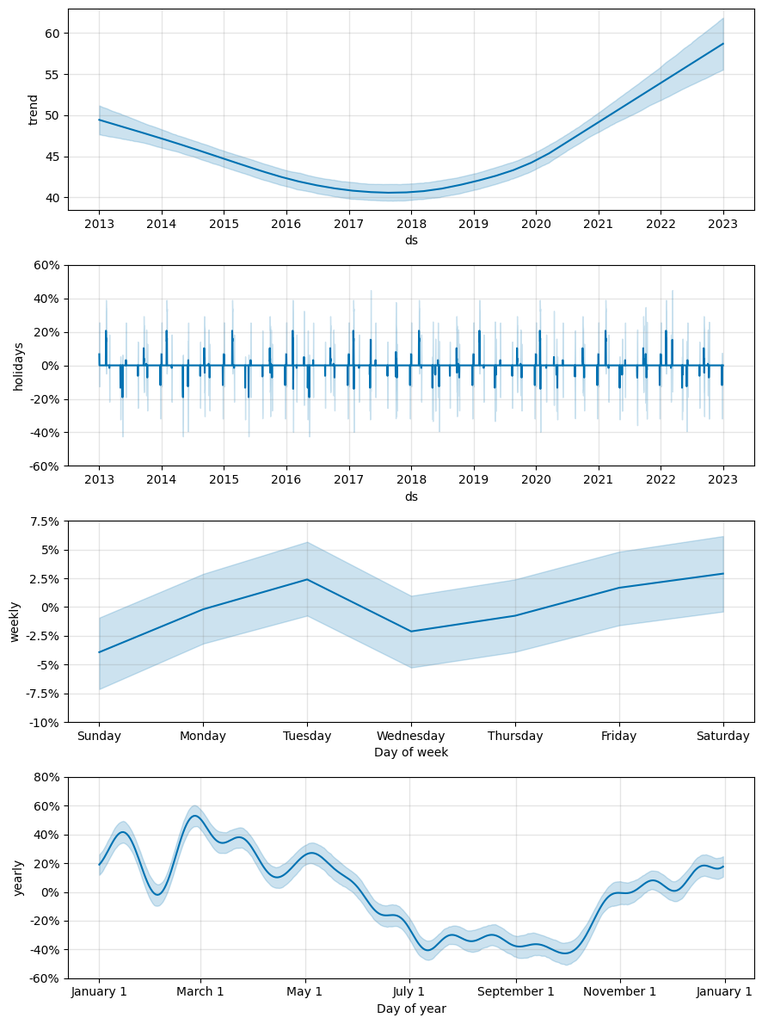

```python
f = m1.plot_components(forecast)
```

1. It shows increasing overall trends across the years
2. Holiday tends to both increase or decrease depend each holiday, not have distinct direction of effect on the fiue dust
3. In weekly trend, it peaks both Tuesday and Saturday. I cannot think out proper reason of for this.
4. In yearly trend, summer gives lowest value and peaks around March, which coincide with above analysis

#### Compare the model, the forecasted value, with actual measured data

```python
utils.make_verif?
```

```
Signature: utils.make_verif(forecast, data_train, data_test)
Docstring:
Put together the forecast (coming from fbprophet)
and the overved data, and set the index to be a proper datetime index,
for plotting

Parameters
----------
forecast : pandas.DataFrame
    The pandas.DataFrame coming from the `forecast` method of a fbprophet
    model.

data_train : pandas.DataFrame
    The training set, pandas.DataFrame

data_test : pandas.DataFrame
    The training set, pandas.DataFrame

Returns
-------
forecast :
    The forecast DataFrane including the original observed data.
File:      c:\users\hyochan heo\appdata\local\programs\python\python310\utils.py
Type:      function
```

```python
verif = utils.make_verif(forecast, data_train, data_test)
```

#### Plot the actual data with predicted data

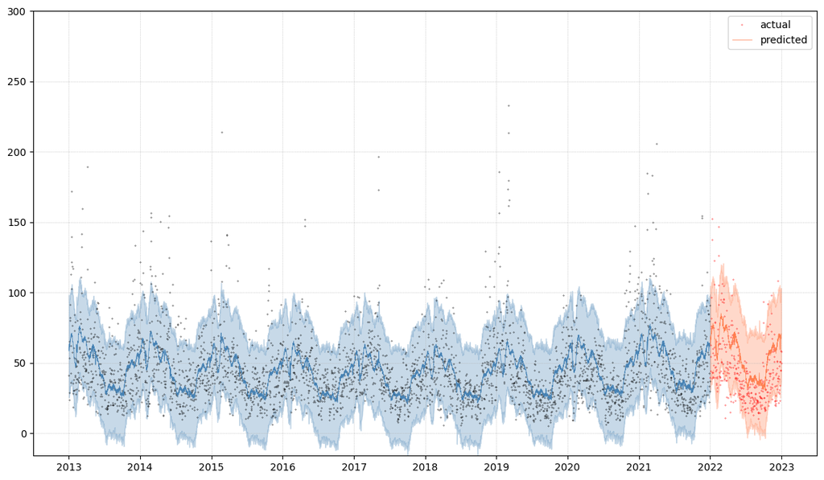

```python
f, ax = plt.subplots(figsize=(14, 8))

train = verif.loc[:'2021',:]

ax.plot(train.index, train.y, 'ko', markersize=0.3)

ax.plot(train.index, train.yhat, color='steelblue', lw=0.5)

ax.fill_between(train.index, train.yhat_lower, train.yhat_upper, color='steelblue', alpha=0.3)

test = verif.loc['2022':,:]

ax.plot(test.index, test.y, 'ro', markersize=0.3, label='actual')

ax.plot(test.index, test.yhat, color='coral', lw=0.5, label='predicted')

ax.fill_between(test.index, test.yhat_lower, test.yhat_upper, color='coral', alpha=0.3)

ax.grid(ls=':', lw=0.5)
ax.set_ylim(-16, 300)
ax.legend()
```

The model shows rough allignment in seasonality, but not clealy coincide with actual data.

#### Marginal distribution and corrlation between model forecasted values with actual measured values

#### On train data

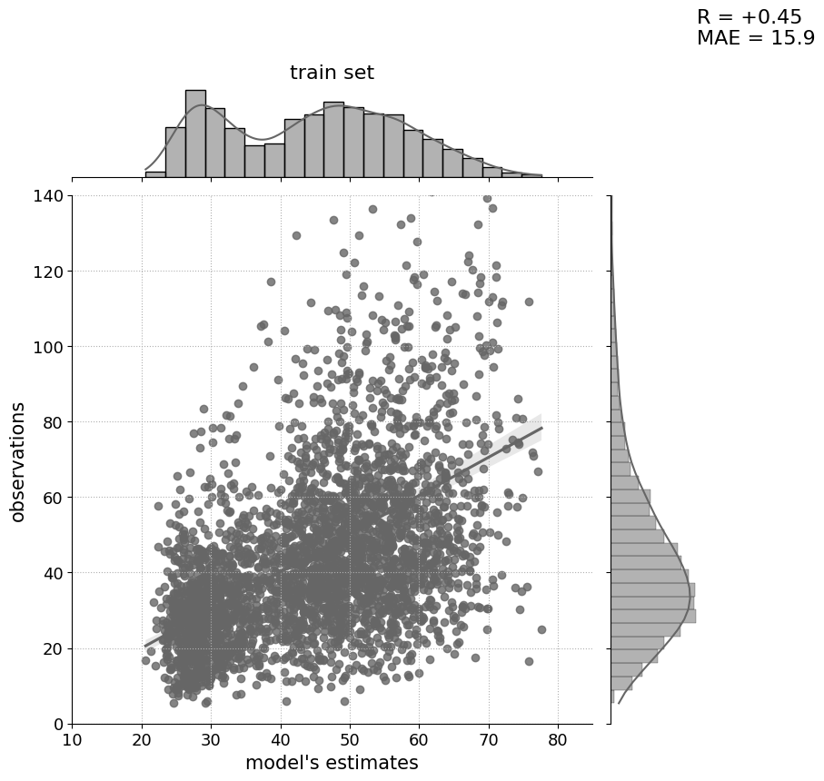

```python
g = sns.jointplot(x='yhat', y='y', data = verif.loc[:'2021',:], kind="reg", color="0.4")
g.ax_joint.set_xlim(10, 85)
g.ax_joint.set_ylim(0, 140)
g.fig.set_figwidth(8)
g.fig.set_figheight(8)
ax = g.fig.axes[1]
ax.set_title('train set', fontsize=16)
ax = g.fig.axes[0]
ax.text(100, 180, "R = {:+4.2f}\nMAE = {:4.1f}".format(verif.loc[:'2021',:].fillna(method='ffill').loc[:,['y','yhat']].corr().iloc[0,1],
        MAE(verif.loc[:'2021',:].fillna(method='ffill').loc[:,'y'].values, verif.loc[:'2021',:].fillna(method='ffill').loc[:,'yhat'].values)), fontsize=16)
ax.set_xlabel("model's estimates", fontsize=15)
ax.set_ylabel("observations", fontsize=15)
ax.grid(ls=':')
[l.set_fontsize(13) for l in ax.xaxis.get_ticklabels()]
[l.set_fontsize(13) for l in ax.yaxis.get_ticklabels()];
ax.grid(ls=':')
```

It shows that the model forecasted values are not stronly correlated with actual values

#### On test data

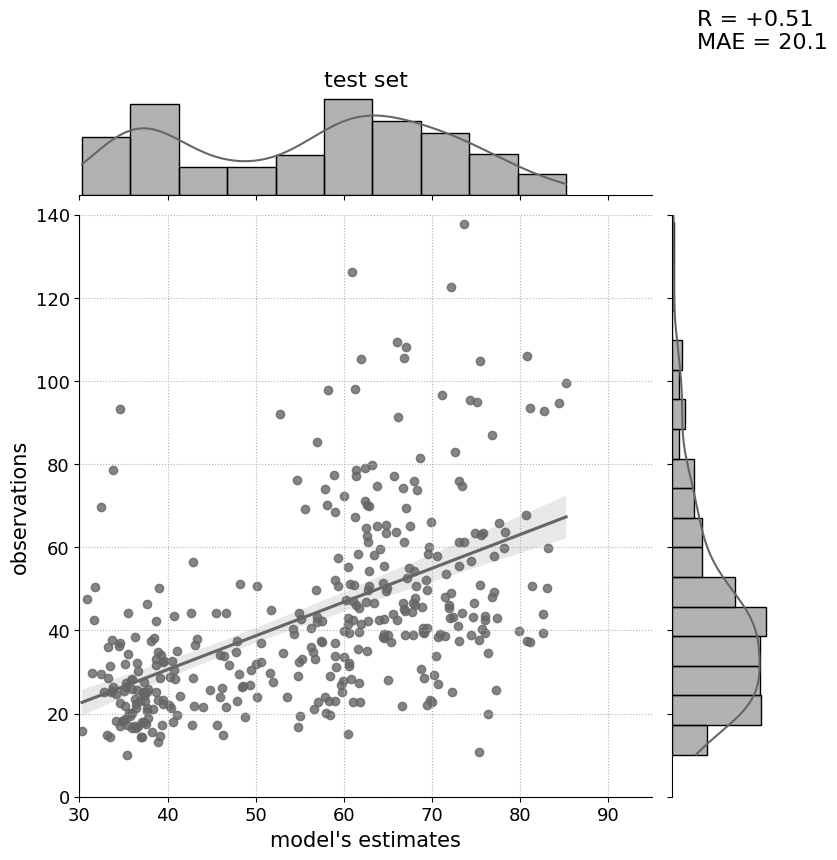

```python
g = sns.jointplot(x='yhat', y='y', data = verif.loc['2022':,:], kind="reg", color="0.4")
g.ax_joint.set_xlim(30, 95)
g.ax_joint.set_ylim(0, 140)
g.fig.set_figwidth(8)
g.fig.set_figheight(8)
ax = g.fig.axes[1]
ax.set_title('test set', fontsize=16)
ax = g.fig.axes[0]
ax.text(100, 180, "R = {:+4.2f}\nMAE = {:4.1f}".format(verif.loc['2022':,:].fillna(method='ffill').loc[:,['y','yhat']].corr().iloc[0,1],
        MAE(verif.loc['2022':,:].fillna(method='ffill').loc[:,'y'].values, verif.loc['2022':,:].fillna(method='ffill').loc[:,'yhat'].values)), fontsize=16)
ax.set_xlabel("model's estimates", fontsize=15)
ax.set_ylabel("observations", fontsize=15)
ax.grid(ls=':')
[l.set_fontsize(13) for l in ax.xaxis.get_ticklabels()]
[l.set_fontsize(13) for l in ax.yaxis.get_ticklabels()];
ax.grid(ls=':')
```

It also shows that the model forecasted values are not stronly correlated with actual values. It suggests that the model predicted not accurately about test dataset.

#### Distribution of residual, on test set

[output not shown]

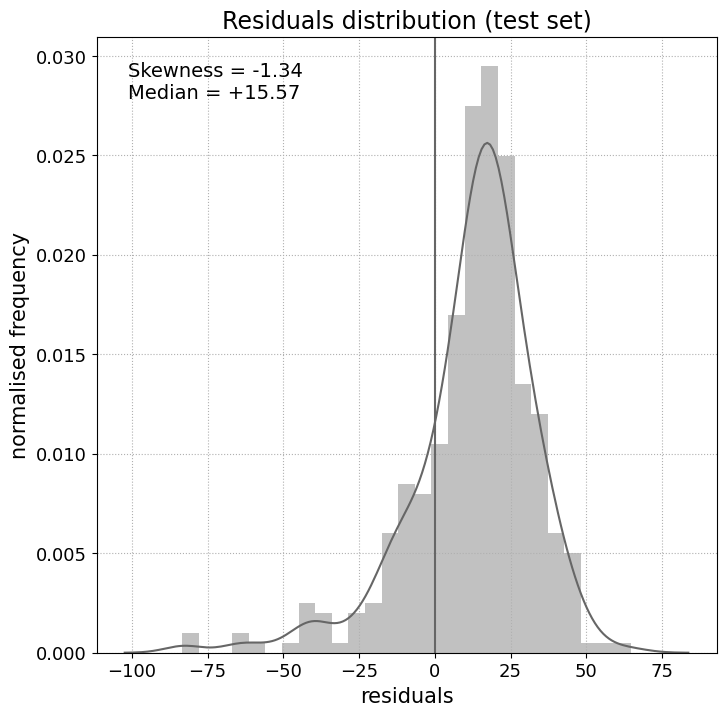

```python
f, ax = plt.subplots(figsize=(8,8))
sns.distplot((verif.loc['2022':,'yhat'] - verif.loc['2022':,'y'].fillna(method='ffill')), ax=ax, color='0.4')
ax.grid(ls=':')
ax.set_xlabel('residuals', fontsize=15)
ax.set_ylabel("normalised frequency", fontsize=15)
ax.grid(ls=':')

[l.set_fontsize(13) for l in ax.xaxis.get_ticklabels()]
[l.set_fontsize(13) for l in ax.yaxis.get_ticklabels()];

ax.text(0.05, 0.9, "Skewness = {:+4.2f}\nMedian = {:+4.2f}".\
        format(skew(verif.loc['2022':,'yhat'] - verif.loc['2022':,'y'].fillna(method='ffill')),
               (verif.loc['2022':,'yhat'] - verif.loc['2022':,'y']).fillna(method='ffill').median()), \
        fontsize=14, transform=ax.transAxes)

ax.axvline(0, color='0.4')

ax.set_title('Residuals distribution (test set)', fontsize=17)
```

### Second Prophet model

#### Incorporating the effects of environmental conditions

#### Rainfall measured at the weather station

```python
rainfall = pd.read_csv("rn_20240220173623.csv", encoding="cp949", skiprows=7, header=0)

rainfall['날짜'] = pd.to_datetime(rainfall['날짜'])
rainfall.set_index('날짜', inplace=True)

rainfall.rename(columns={'강수량(mm)': 'rainfall'}, inplace=True)
rainfall = rainfall[['rainfall']]
rainfall.fillna(0, inplace=True)

rainfall
```

| 날짜 | rainfall |
| --- | --- |
| 2013-01-01 | 5.1 |
| 2013-01-02 | 0.0 |
| 2013-01-03 | 0.0 |
| 2013-01-04 | 0.0 |
| 2013-01-05 | 0.0 |
| ... | ... |
| 2022-12-27 | 0.0 |
| 2022-12-28 | 0.9 |
| 2022-12-29 | 0.0 |
| 2022-12-30 | 0.3 |
| 2022-12-31 | 0.0 |

3652 rows × 1 columns

#### The most wind direction at each day, measured near the weather station

```python
wind_direc = pd.read_csv("OBS_ASOS_DD_20240220214638.csv", encoding="cp949", header=0)

wind_direc['일시'] = pd.to_datetime(wind_direc['일시'])
wind_direc.set_index('일시', inplace=True)

wind_direc.rename(columns={'최다풍향(16방위)': 'wind_direc'}, inplace=True)
wind_direc = wind_direc[['wind_direc']]

wind_direc
```

| 일시 | wind_direc |
| --- | --- |
| 2013-01-01 | 90 |
| 2013-01-02 | 320 |
| 2013-01-03 | 290 |
| 2013-01-04 | 180 |
| 2013-01-05 | 270 |
| ... | ... |
| 2022-12-27 | 290 |
| 2022-12-28 | 290 |
| 2022-12-29 | 250 |
| 2022-12-30 | 270 |
| 2022-12-31 | 140 |

3651 rows × 1 columns

#### Nationwide Traffic volume in South Korea

The dataset contains both csv format data and txt format data

```python
traffic_csv = glob("trafficascsv/TCS_??_??_??_??????.csv")
```

```python
l = []
for f in traffic_csv:
    #d = pd.read_csv(f, index_col=1, parse_dates=True, encoding="cp949")
    d = pd.read_csv(f, encoding='cp949')
    max_traffic_per_day = d.groupby('집계일자')['총교통량'].max().reset_index()
    #d.rename(columns={'1시간평균 미세먼지농도(㎍/㎥)': 'fdust_per_h'}, inplace=True)
    l.append(max_traffic_per_day)
l
trafficcsv = pd.concat(l, axis=0)
trafficcsv
```

|  | 집계일자 | 총교통량 |
| --- | --- | --- |
| 0 | 20140801 | 81313 |
| 1 | 20140802 | 72678 |
| 2 | 20140803 | 63147 |
| 3 | 20140804 | 72235 |
| 4 | 20140805 | 74235 |
| ... | ... | ... |
| 24 | 20200225 | 80093 |
| 25 | 20200226 | 85741 |
| 26 | 20200227 | 87007 |
| 27 | 20200228 | 86609 |
| 28 | 20200229 | 74386 |

1795 rows × 2 columns

```python
traffic_txt = glob("trafficastext/TCS_??_??_??_??????.txt")
```

```python
l = []
for f in traffic_txt:
    d = pd.read_csv(f, encoding='cp949', delimiter='|')
    d.columns = ['집계일자', 'Code1', 'Code2', 'Code3', 'Traffic1', 'Traffic2', 'Traffic3', 'Traffic4', 'Traffic5', 'Traffic6', '총교통량', 'Unnamed']
    max_traffic_per_day = d.groupby('집계일자')['총교통량'].max().reset_index()
    l.append(max_traffic_per_day)
l
traffictxt = pd.concat(l, axis=0)
traffictxt
```

|  | 집계일자 | 총교통량 |
| --- | --- | --- |
| 0 | 20151001 | 74300.0 |
| 1 | 20151002 | 83838.0 |
| 2 | 20151003 | 82159.0 |
| 3 | 20151004 | 74399.0 |
| 4 | 20151005 | 82410.0 |
| ... | ... | ... |
| 25 | 20191227 | NaN |
| 26 | 20191228 | NaN |
| 27 | 20191229 | NaN |
| 28 | 20191230 | NaN |
| 29 | 20191231 | NaN |

1832 rows × 2 columns

```python
traffic = pd.concat([traffictxt, trafficcsv], axis=0).sort_values(by='집계일자')
traffic.rename(columns={'총교통량': 'traffic'}, inplace=True)
traffic['집계일자'] = pd.to_datetime(traffic['집계일자'], format='%Y%m%d')
traffic = traffic.set_index('집계일자')
traffic
```

| 집계일자 | traffic |
| --- | --- |
| 2013-01-01 | 44266.0 |
| 2013-01-02 | 55828.0 |
| 2013-01-03 | 58689.0 |
| 2013-01-04 | 64195.0 |
| 2013-01-05 | 57335.0 |
| ... | ... |
| 2022-12-27 | 92067.0 |
| 2022-12-28 | 92154.0 |
| 2022-12-29 | 92561.0 |
| 2022-12-30 | 92624.0 |
| 2022-12-31 | 82540.0 |

3627 rows × 1 columns

#### Covid new case for each day at worldwide

To incorperate covid event in the model

```python
covid = pd.read_csv("owid-covid-data.csv")

covid = covid[covid['location'] == 'World']
covid['date'] = pd.to_datetime(covid['date'])
covid.set_index('date', inplace=True)
covid = covid[['new_cases_smoothed']].rename(columns={'new_cases_smoothed': 'covid'})
date_range = pd.date_range(start='2013-01-01', end='2022-12-31')
covid = covid.reindex(date_range).fillna(0)

covid
```

```
C:\Users\Hyochan Heo\AppData\Local\Temp\ipykernel_26604\3473118954.py:1: DtypeWarning: Columns (33) have mixed types. Specify dtype option on import or set low_memory=False.
  covid = pd.read_csv("owid-covid-data.csv")
```

|  | covid |
| --- | --- |
| 2013-01-01 | 0.0 |
| 2013-01-02 | 0.0 |
| 2013-01-03 | 0.0 |
| 2013-01-04 | 0.0 |
| 2013-01-05 | 0.0 |
| ... | ... |
| 2022-12-27 | 6319461.0 |
| 2022-12-28 | 6319461.0 |
| 2022-12-29 | 6319461.0 |
| 2022-12-30 | 6319461.0 |
| 2022-12-31 | 6319461.0 |

3652 rows × 1 columns

#### Interpolate the data for missing values

```python
rainfall = rainfall.interpolate(method='linear')
wind_direc = wind_direc.interpolate(method='linear')
traffic = traffic.interpolate(method='linear')

rainfall.fillna(0, inplace=True)
wind_direc.fillna(0, inplace=True)
traffic.fillna(0, inplace=True)
```

#### Prepare regressor dataframe contains these environmental variables

```python
data_with_regressors = utils.add_regressor(data, rainfall, varname='rainfall')
data_with_regressors = utils.add_regressor(data_with_regressors, wind_direc, varname='wind_direc')
data_with_regressors = utils.add_regressor(data_with_regressors, traffic, varname='traffic')
data_with_regressors = utils.add_regressor(data_with_regressors, covid, varname='covid')

data_with_regressors
```

|  | y | rainfall | wind_direc | traffic | covid |
| --- | --- | --- | --- | --- | --- |
| 2013-01-01 | 41.173913 | 5.1 | 90.0 | 44266.0 | 0.0 |
| 2013-01-02 | 23.750000 | 0.0 | 320.0 | 55828.0 | 0.0 |
| 2013-01-03 | 29.000000 | 0.0 | 290.0 | 58689.0 | 0.0 |
| 2013-01-04 | 53.458333 | 0.0 | 180.0 | 64195.0 | 0.0 |
| 2013-01-05 | 65.333333 | 0.0 | 270.0 | 57335.0 | 0.0 |
| ... | ... | ... | ... | ... | ... |
| 2022-12-27 | 58.416667 | 0.0 | 290.0 | 92067.0 | 6319461.0 |
| 2022-12-28 | 44.791667 | 0.9 | 290.0 | 92154.0 | 6319461.0 |
| 2022-12-29 | 44.500000 | 0.0 | 250.0 | 92561.0 | 6319461.0 |
| 2022-12-30 | 49.625000 | 0.3 | 270.0 | 92624.0 | 6319461.0 |
| 2022-12-31 | 57.875000 | 0.0 | 140.0 | 82540.0 | 6319461.0 |

3652 rows × 5 columns

#### prepare the train and test dataset

Last one year is dedicated for test data as same as first model

```python
data_train, data_test = utils.prepare_data(data_with_regressors, 2022)
```

#### Confirm there is no missing value in data

```python
data_train = data_train.rename({'index':'ds'}, axis=1)
data_train
data_train.isna().sum()
```

```
ds             0
y             13
rainfall       0
wind_direc     1
traffic       25
covid          0
dtype: int64
```

Replace the empty value with 0, as expected having not such impact on the model, because missing values are tiny portion among data

```python
data_train.fillna(0, inplace=True)
data_train.isna().sum()
```

```
ds            0
y             0
rainfall      0
wind_direc    0
traffic       0
covid         0
dtype: int64
```

#### Confirm the data

```python
data_test = data_test.rename({'index':'ds'}, axis=1)
data_test
```

|  | ds | y | rainfall | wind_direc | traffic | covid |
| --- | --- | --- | --- | --- | --- | --- |
| 0 | 2022-01-01 | 39.333333 | 0.0 | 140.0 | 72553.0 | 870046.714 |
| 1 | 2022-01-02 | 62.625000 | 0.5 | 250.0 | 74305.0 | 1495546.857 |
| 2 | 2022-01-03 | 43.916667 | 0.0 | 290.0 | 90450.0 | 1495546.857 |
| 3 | 2022-01-04 | 54.208333 | 0.0 | 320.0 | 87512.0 | 1495546.857 |
| 4 | 2022-01-05 | 74.375000 | 0.0 | 270.0 | 88482.0 | 1495546.857 |
| ... | ... | ... | ... | ... | ... | ... |
| 360 | 2022-12-27 | 58.416667 | 0.0 | 290.0 | 92067.0 | 6319461.000 |
| 361 | 2022-12-28 | 44.791667 | 0.9 | 290.0 | 92154.0 | 6319461.000 |
| 362 | 2022-12-29 | 44.500000 | 0.0 | 250.0 | 92561.0 | 6319461.000 |
| 363 | 2022-12-30 | 49.625000 | 0.3 | 270.0 | 92624.0 | 6319461.000 |
| 364 | 2022-12-31 | 57.875000 | 0.0 | 140.0 | 82540.0 | 6319461.000 |

365 rows × 6 columns

#### The second prophet model, used same hyperparameters as first model.

The only difference is additional regressor is incorporated

```python
m = Prophet(mcmc_samples=300, holidays=holidays_df, holidays_prior_scale=0.25, changepoint_prior_scale=0.005, seasonality_mode='multiplicative', \
            yearly_seasonality=15, \
            weekly_seasonality=True, \
            daily_seasonality=False)
```

```python
m.add_regressor('rainfall', prior_scale=0.4, mode='multiplicative')
m.add_regressor('wind_direc', prior_scale=0.4, mode='multiplicative')
m.add_regressor('traffic', prior_scale=0.4, mode='multiplicative')
m.add_regressor('covid', prior_scale=0.4, mode='multiplicative')
```

```
<prophet.forecaster.Prophet at 0x292c166cbe0>
```

#### Fit the model on train dataset

```python
m.fit(data_train)
```

[output not shown]

[output not shown]

```
<prophet.forecaster.Prophet at 0x292c166cbe0>
```

#### Make the future DataFrame

```python
future = m.make_future_dataframe(periods=len(data_test), freq='1D')
```

```python
futures = utils.add_regressor_to_future(future, [rainfall, wind_direc, traffic, covid])
```

```python
futures
```

|  | ds | rainfall | wind_direc | traffic | covid |
| --- | --- | --- | --- | --- | --- |
| 0 | 2013-01-01 | 5.1 | 90.0 | 44266.0 | 0.0 |
| 1 | 2013-01-02 | 0.0 | 320.0 | 55828.0 | 0.0 |
| 2 | 2013-01-03 | 0.0 | 290.0 | 58689.0 | 0.0 |
| 3 | 2013-01-04 | 0.0 | 180.0 | 64195.0 | 0.0 |
| 4 | 2013-01-05 | 0.0 | 270.0 | 57335.0 | 0.0 |
| ... | ... | ... | ... | ... | ... |
| 3647 | 2022-12-27 | 0.0 | 290.0 | 92067.0 | 6319461.0 |
| 3648 | 2022-12-28 | 0.9 | 290.0 | 92154.0 | 6319461.0 |
| 3649 | 2022-12-29 | 0.0 | 250.0 | 92561.0 | 6319461.0 |
| 3650 | 2022-12-30 | 0.3 | 270.0 | 92624.0 | 6319461.0 |
| 3651 | 2022-12-31 | 0.0 | 140.0 | 82540.0 | 6319461.0 |

3652 rows × 5 columns

#### Make sure the data have no missing value

```python
futures.fillna(0, inplace=True)
futures.isna().sum()
```

```
ds            0
rainfall      0
wind_direc    0
traffic       0
covid         0
dtype: int64
```

#### Forecast

```python
forecast = m.predict(futures)
```

#### Plots the components of the forecast

It includes overall trend, cyclic trend (weekly and yearly), effect of each holidays, effect of additional regressor

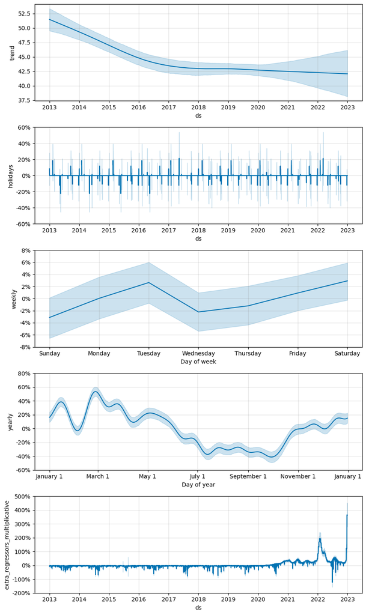

```python
f = m.plot_components(forecast)
```

1. It shows decrease in overall trends across the years, opposite to first model
2. Holiday tends to both increase or decrease depend each holiday, not have distinct direction of effect on the fiue dust
3. In weekly trend, it peaks both Tuesday and Saturday. Agree with first model
4. In yearly trend, summer gives lowest value and peaks around March, agree with first model.
5. Additional regressors, before Covid event, it gives seasonal decrease. I think this is because rainfall and finedust are both correlated with summer
6. Additional regressors, on Covid periods, it gives increase effect, and the shape of trend looks simmilar with Covid new case trend. I think the model recognize variable "covid" as the increasing factor.

The opposite result on overall trend, as mentioned in 1., might because the first model considered the increase of fine dust as the trend of finedust itself, while the second model perceives the increase of fine dust as the result of Covid regressor.

#### Plot the Covid new case trend, for the comparision effect of extra regressor

as mentioned 6.

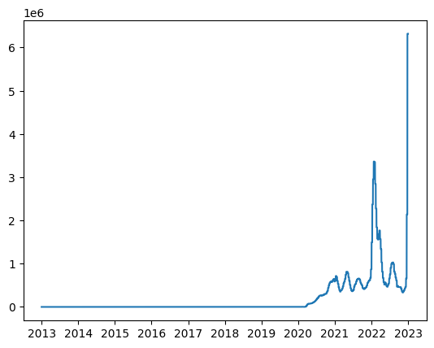

```python
plt.plot(covid.index, covid['covid'])
```

As mentioned above, this Covid new case trend shows similar shape with extra regressors effect. Note that the model trained with the fine dust data due to end of 2021, and does not meeted the actual value when Covid new cases abrupt increases and peaks after 2021. Thus it might overestimate Covid effect on the time periods after 2021.

#### Compare the model, the forecasted value, with actual measured data

```python
verif = utils.make_verif(forecast, data_train, data_test)
```

```python
verif
```

| ds | ds | trend | yhat_lower | yhat_upper | trend_lower | trend_upper | covid | covid_lower | covid_upper | extra_regressors_multiplicative | ... | 한글날 대체 휴일_lower | 한글날 대체 휴일_upper | 현충일 | 현충일_lower | 현충일_upper | additive_terms | additive_terms_lower | additive_terms_upper | yhat | y |
| --- | --- | --- | --- | --- | --- | --- | --- | --- | --- | --- | --- | --- | --- | --- | --- | --- | --- | --- | --- | --- | --- |
| 2013-01-01 | 2013-01-01 | 51.485466 | 26.630169 | 95.990688 | 49.530639 | 53.375135 | -0.049502 | -0.061334 | -0.038109 | -0.080560 | ... | 0.0 | 0.0 | 0.0 | 0.0 | 0.0 | 0.0 | 0.0 | 0.0 | 61.398339 | 41.173913 |
| 2013-01-02 | 2013-01-02 | 51.479612 | 24.953548 | 91.394050 | 49.526538 | 53.365667 | -0.049502 | -0.061334 | -0.038109 | -0.014434 | ... | 0.0 | 0.0 | 0.0 | 0.0 | 0.0 | 0.0 | 0.0 | 0.0 | 58.636209 | 23.750000 |
| 2013-01-03 | 2013-01-03 | 51.473758 | 24.269026 | 92.976901 | 49.522438 | 53.356857 | -0.049502 | -0.061334 | -0.038109 | -0.019480 | ... | 0.0 | 0.0 | 0.0 | 0.0 | 0.0 | 0.0 | 0.0 | 0.0 | 59.697006 | 29.000000 |
| 2013-01-04 | 2013-01-04 | 51.467904 | 27.366122 | 94.636669 | 49.518364 | 53.348672 | -0.049502 | -0.061334 | -0.038109 | -0.037890 | ... | 0.0 | 0.0 | 0.0 | 0.0 | 0.0 | 0.0 | 0.0 | 0.0 | 60.761871 | 53.458333 |
| 2013-01-05 | 2013-01-05 | 51.462050 | 31.086928 | 97.118686 | 49.514704 | 53.340486 | -0.049502 | -0.061334 | -0.038109 | -0.022783 | ... | 0.0 | 0.0 | 0.0 | 0.0 | 0.0 | 0.0 | 0.0 | 0.0 | 63.586339 | 65.333333 |
| ... | ... | ... | ... | ... | ... | ... | ... | ... | ... | ... | ... | ... | ... | ... | ... | ... | ... | ... | ... | ... | ... |
| 2022-12-27 | 2022-12-27 | 42.077479 | 163.043454 | 242.137725 | 38.170997 | 46.143508 | 3.626158 | 2.791608 | 4.492932 | 3.655551 | ... | 0.0 | 0.0 | 0.0 | 0.0 | 0.0 | 0.0 | 0.0 | 0.0 | 202.843206 | 58.416667 |
| 2022-12-28 | 2022-12-28 | 42.076905 | 157.666057 | 240.242835 | 38.167151 | 46.145586 | 3.626158 | 2.791608 | 4.492932 | 3.650597 | ... | 0.0 | 0.0 | 0.0 | 0.0 | 0.0 | 0.0 | 0.0 | 0.0 | 200.550084 | 44.791667 |
| 2022-12-29 | 2022-12-29 | 42.076331 | 158.367636 | 240.865765 | 38.163305 | 46.147663 | 3.626158 | 2.791608 | 4.492932 | 3.648886 | ... | 0.0 | 0.0 | 0.0 | 0.0 | 0.0 | 0.0 | 0.0 | 0.0 | 200.948821 | 44.500000 |
| 2022-12-30 | 2022-12-30 | 42.075757 | 159.970221 | 242.247408 | 38.159460 | 46.150491 | 3.626158 | 2.791608 | 4.492932 | 3.650562 | ... | 0.0 | 0.0 | 0.0 | 0.0 | 0.0 | 0.0 | 0.0 | 0.0 | 202.055061 | 49.625000 |
| 2022-12-31 | 2022-12-31 | 42.075182 | 160.417512 | 239.032547 | 38.155614 | 46.155563 | 3.626158 | 2.791608 | 4.492932 | 3.630768 | ... | 0.0 | 0.0 | 0.0 | 0.0 | 0.0 | 0.0 | 0.0 | 0.0 | 202.317220 | 57.875000 |

3652 rows × 119 columns

#### Plot the actual data with predicted data

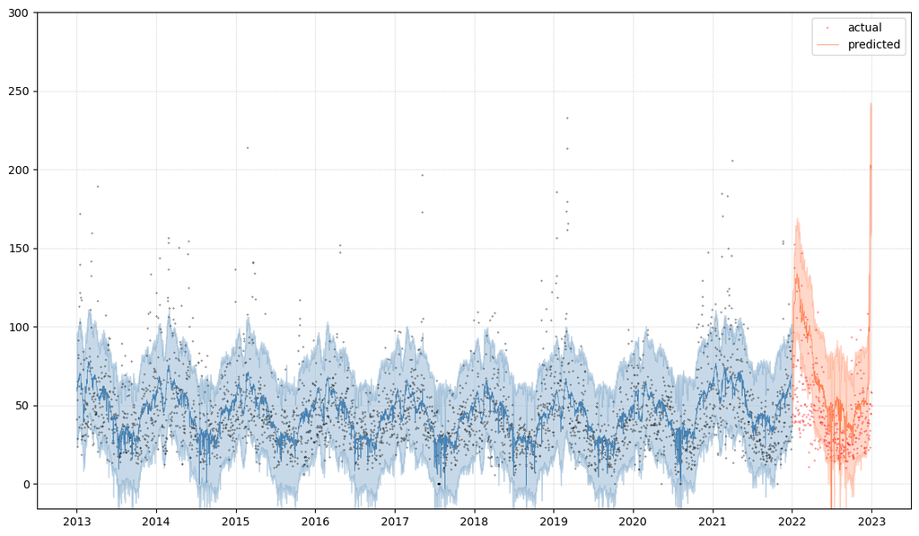

```python
f, ax = plt.subplots(figsize=(14, 8))

train = verif.loc[:'2021',:]

ax.plot(train.index, train.y, 'ko', markersize=0.3)

ax.plot(train.index, train.yhat, color='steelblue', lw=0.5)

ax.fill_between(train.index, train.yhat_lower, train.yhat_upper, color='steelblue', alpha=0.3)

test = verif.loc['2022':,:]

ax.plot(test.index, test.y, 'ro', markersize=0.3, label='actual')

ax.plot(test.index, test.yhat, color='coral', lw=0.5, label='predicted')

ax.fill_between(test.index, test.yhat_lower, test.yhat_upper, color='coral', alpha=0.3)

ax.grid(ls=':', lw=0.5)
ax.set_ylim(-16, 300)
ax.legend()
```

The model shows rough allignment in seasonality, but not clealy coincide with actual data. Especially in 2022 the predicted value is much higher than actual value. This might because the abrupt increase of Covid new case at the peroids, as mentioned.

#### Marginal distribution and corrlation between model forecasted values with actual measured values

#### On train data

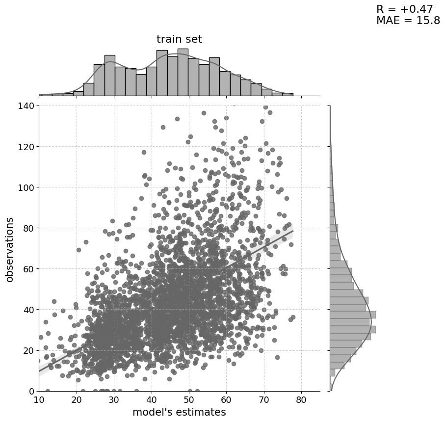

```python
g = sns.jointplot(x='yhat', y='y', data = verif.loc[:'2021',:], kind="reg", color="0.4")
g.ax_joint.set_xlim(10, 85)
g.ax_joint.set_ylim(0, 140)
g.fig.set_figwidth(8)
g.fig.set_figheight(8)
ax = g.fig.axes[1]
ax.set_title('train set', fontsize=16)
ax = g.fig.axes[0]
ax.text(100, 180, "R = {:+4.2f}\nMAE = {:4.1f}".format(verif.loc[:'2021',:].fillna(method='ffill').loc[:,['y','yhat']].corr().iloc[0,1],
        MAE(verif.loc[:'2021',:].fillna(method='ffill').loc[:,'y'].values, verif.loc[:'2021',:].fillna(method='ffill').loc[:,'yhat'].values)), fontsize=16)
ax.set_xlabel("model's estimates", fontsize=15)
ax.set_ylabel("observations", fontsize=15)
ax.grid(ls=':')
[l.set_fontsize(13) for l in ax.xaxis.get_ticklabels()]
[l.set_fontsize(13) for l in ax.yaxis.get_ticklabels()];
ax.grid(ls=':')
```

It shows that the model forecasted values are not stronly correlated with actual values, a little bit increased correlation compared to first model (from 0.45 to 0.47).

#### On test data

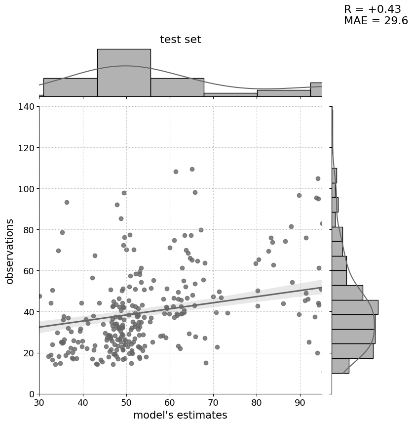

```python
g = sns.jointplot(x='yhat', y='y', data = verif.loc['2022':,:], kind="reg", color="0.4")
g.ax_joint.set_xlim(30, 95)
g.ax_joint.set_ylim(0, 140)
g.fig.set_figwidth(8)
g.fig.set_figheight(8)
ax = g.fig.axes[1]
ax.set_title('test set', fontsize=16)
ax = g.fig.axes[0]
ax.text(100, 180, "R = {:+4.2f}\nMAE = {:4.1f}".format(verif.loc['2022':,:].fillna(method='ffill').loc[:,['y','yhat']].corr().iloc[0,1],
        MAE(verif.loc['2022':,:].fillna(method='ffill').loc[:,'y'].values, verif.loc['2022':,:].fillna(method='ffill').loc[:,'yhat'].values)), fontsize=16)
ax.set_xlabel("model's estimates", fontsize=15)
ax.set_ylabel("observations", fontsize=15)
ax.grid(ls=':')
[l.set_fontsize(13) for l in ax.xaxis.get_ticklabels()]
[l.set_fontsize(13) for l in ax.yaxis.get_ticklabels()];
ax.grid(ls=':')
```

It gives worse correlation compared first model (from 0.51 to 0.43), suggesting the information from addtional regressors provided no meaningful information for constructing model for fine dust data. It still shows that the model forecasted values are not stronly correlated with actual values, suggesting that the model predicted poorly about test dataset.

#### Distribution of residual, on test set

[output not shown]

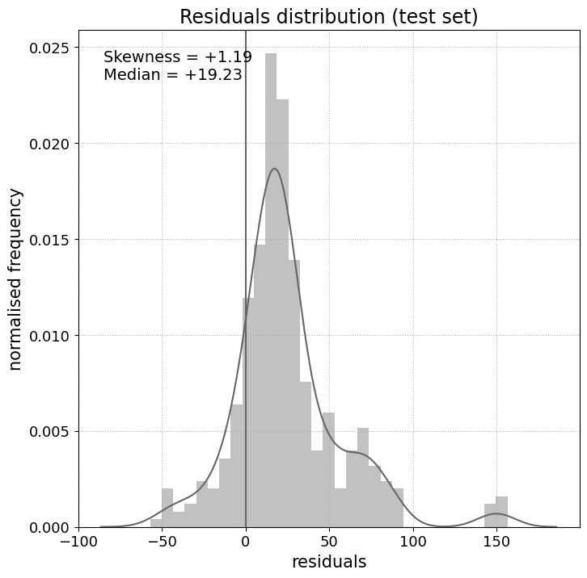

```python
f, ax = plt.subplots(figsize=(8,8))
sns.distplot((verif.loc['2022':,'yhat'] - verif.loc['2022':,'y'].fillna(method='ffill')), ax=ax, color='0.4')
ax.grid(ls=':')
ax.set_xlabel('residuals', fontsize=15)
ax.set_ylabel("normalised frequency", fontsize=15)
ax.grid(ls=':')

[l.set_fontsize(13) for l in ax.xaxis.get_ticklabels()]
[l.set_fontsize(13) for l in ax.yaxis.get_ticklabels()];

ax.text(0.05, 0.9, "Skewness = {:+4.2f}\nMedian = {:+4.2f}".\
        format(skew(verif.loc['2022':,'yhat'] - verif.loc['2022':,'y'].fillna(method='ffill')),
               (verif.loc['2022':,'yhat'] - verif.loc['2022':,'y']).fillna(method='ffill').median()), \
        fontsize=14, transform=ax.transAxes)

ax.axvline(0, color='0.4')

ax.set_title('Residuals distribution (test set)', fontsize=17)
```

Although the model is not accurate, now examine the effect of each regressors on fine dust concentration

#### Plot the contribution of the different environmental variables to the response variable

(in percentage of the trend component, as we chose a multiplicative model)

```python
# f = utils.plot_verif_component(verif, component = 'traffic', year=2022)
```

#### Rainfall

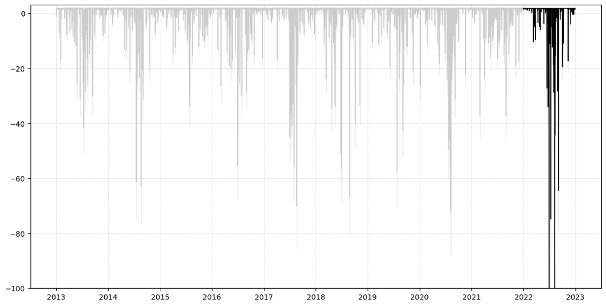

```python
component = 'rainfall'
year = '2022'

f, ax = plt.subplots(figsize=(14, 7))

train = verif.loc[:'2021',:]

ax.plot(train.index, train.loc[:,component] * 100, color='0.8', lw=1, ls='-')

ax.fill_between(train.index, train.loc[:, component+'_lower'] * 100, train.loc[:, component+'_upper'] * 100, color='0.8', alpha=0.3)

test = verif.loc[str(year):,:]

ax.plot(test.index, test.loc[:,component] * 100, color='k', lw=1, ls='-')

ax.fill_between(test.index, test.loc[:, component+'_lower'] * 100, test.loc[:, component+'_upper'] * 100, color='0.8', alpha=0.3)

#ax.axvline(str(year), color='k', alpha=0.7)

ax.set_ylim([-100, 3])

ax.grid(ls=':', lw=0.5)
```

It suggests rainfall certainly contributing at decrease of fine dust concentration, as suggested before by seasonality of extra regressor effect.

#### Wind_direc

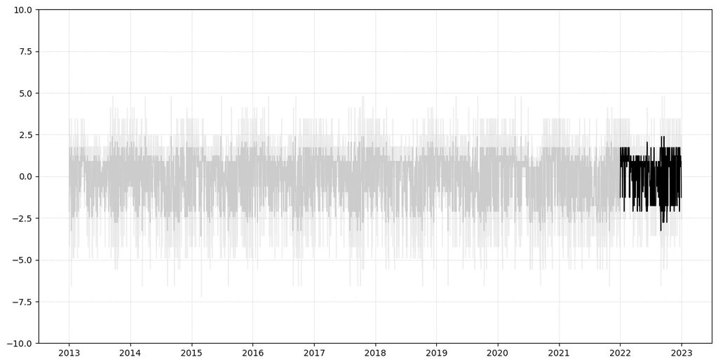

```python
component = 'wind_direc'
year = '2022'

f, ax = plt.subplots(figsize=(14, 7))

train = verif.loc[:'2021',:]

ax.plot(train.index, train.loc[:,component] * 100, color='0.8', lw=1, ls='-')

ax.fill_between(train.index, train.loc[:, component+'_lower'] * 100, train.loc[:, component+'_upper'] * 100, color='0.8', alpha=0.3)

test = verif.loc[str(year):,:]

ax.plot(test.index, test.loc[:,component] * 100, color='k', lw=1, ls='-')

ax.fill_between(test.index, test.loc[:, component+'_lower'] * 100, test.loc[:, component+'_upper'] * 100, color='0.8', alpha=0.3)

#ax.axvline(str(year), color='k', alpha=0.7)

ax.set_ylim([-10, 10])

ax.grid(ls=':', lw=0.5)
```

It shows some seasonal trend, but not so strong effect on the fine dust.

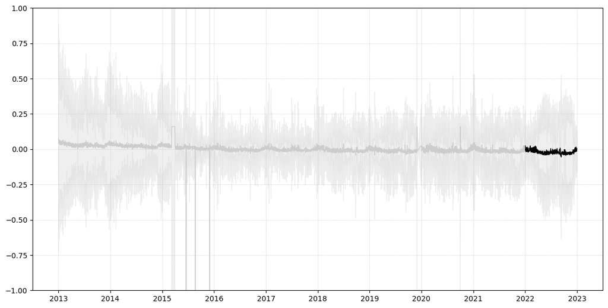

```python
component = 'traffic'
year = '2022'

f, ax = plt.subplots(figsize=(14, 7))

train = verif.loc[:'2021',:]

ax.plot(train.index, train.loc[:,component] * 100, color='0.8', lw=1, ls='-')

ax.fill_between(train.index, train.loc[:, component+'_lower'] * 100, train.loc[:, component+'_upper'] * 100, color='0.8', alpha=0.3)

test = verif.loc[str(year):,:]

ax.plot(test.index, test.loc[:,component] * 100, color='k', lw=1, ls='-')

ax.fill_between(test.index, test.loc[:, component+'_lower'] * 100, test.loc[:, component+'_upper'] * 100, color='0.8', alpha=0.3)

#ax.axvline(str(year), color='k', alpha=0.7)

ax.set_ylim([-1,1])

ax.grid(ls=':', lw=0.5)
```

It suggests the fine dust concentration is independent from traffic volume of Korea.

#### Covid

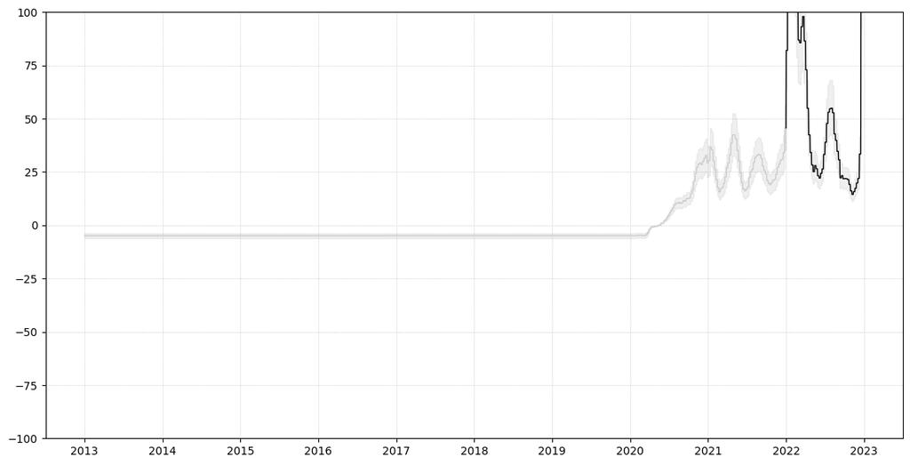

```python
component = 'covid'
year = '2022'

f, ax = plt.subplots(figsize=(14, 7))

train = verif.loc[:'2021',:]

ax.plot(train.index, train.loc[:,component] * 100, color='0.8', lw=1, ls='-')

ax.fill_between(train.index, train.loc[:, component+'_lower'] * 100, train.loc[:, component+'_upper'] * 100, color='0.8', alpha=0.3)

test = verif.loc[str(year):,:]

ax.plot(test.index, test.loc[:,component] * 100, color='k', lw=1, ls='-')

ax.fill_between(test.index, test.loc[:, component+'_lower'] * 100, test.loc[:, component+'_upper'] * 100, color='0.8', alpha=0.3)

#ax.axvline(str(year), color='k', alpha=0.7)

ax.set_ylim([-100, 100])

ax.grid(ls=':', lw=0.5)
```

It suggested Covid strongly contributed to fine dust concentration. Note that I suggested the model may overestimating the Covid effect.